# Coursework Report

*N* removed NAs: 2

*N* removed typo: 1

*N* removed <18: 34

*N* total clean: 114

| Group | *N* | *M*<sub>age</sub> | *M*<sub>rating</sub> |
| --- | --- | --- | --- |
| Control | 58 | 21.22 | 5.33 |
| Experim | 56 | 20.98 | 6.57 |

**Main analysis results**

*t*(112) = -9.76, *p* < .001

[interactive chart not shown]

[figure not shown]

[interactive chart not shown]

# Coursework Report

Analysing Data, Spring 2020

# Methods

## Participants

Table 1 Descriptive statistics by Condition

| Condition | N | % | M<sub>age</sub> | SD<sub>age</sub> |
| --- | --- | --- | --- | --- |
| control | 58 | 50.88 | 21.22 | 2.09 |
| experimental | 56 | 49.12 | 20.98 | 2.46 |

## Design

The aim of this experiment was to investigate the effect of the colour red on women’s attraction to men. To do that participants were presented with a black-and-white photo of a man on a white (n = 58) or red (n = 56) background for 5 s and then reported their perceptions of the man’s attractiveness in a questionnaire. The questionnaire contained 11 items on topics relating to the man’s attractiveness, rated on 9-point scales ranging from, for example, 1 (not at all attractive) to 9 (extremely attractive), and scores were averaged to form a composite index. Data on participants’ own age and gender were also collected. It was hypothesised that women’s composite ratings of the man’s attractiveness would be higher in the experimental condition. ResuLts were interpreted using a Two-Sample t-test.

[output not shown]

# Results

Results from the Two-Sample t-test supported the experimental hypothesis, since there was a difference between the means in the two conditions (*M*<sub>diff</sub> = -1.24, 95% CI [-1.5, -0.99]) and there was a significant difference between the two groups on ratings of attraction (*t* (112) = -9.76, *p* = 0).

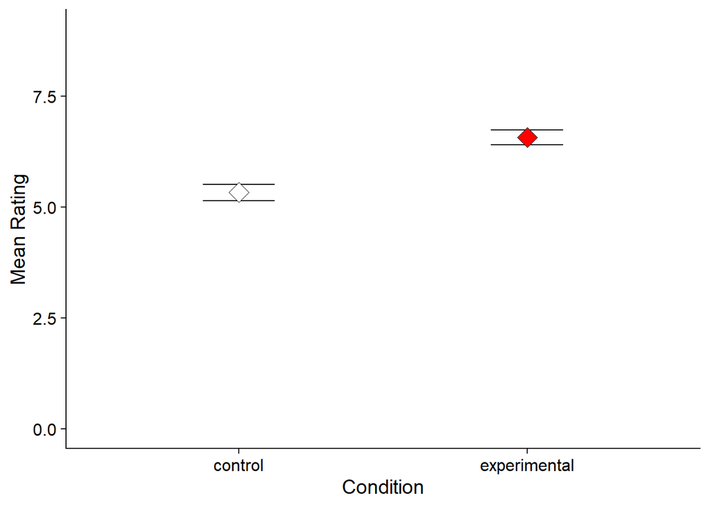

# Discussion

It is concluded that, as predicted, the colour red does affect women’s perception of a man’s attractiveness. Results of this replication of Experiment 1 in Elliot, et al. (2010)’s study, are in accordance with the original experiment, thus increasing the reliability of the findings. However, it would be important to invastigate this hypothesis in other coultures as most of the replications of this experiment have been on wester cultures.

# References